# Salaries_Codes

Isa Allahverdiyev and Umur Kizildas

2023-09-15

#Loading Packages

```r
library(tm)
library(textclean)
library(textstem)
library(tidytext)
library(caret)
library(dplyr)
```

```r
library(tidyr)
library(ggplot2)
library(caret)
library(rpart)
library(randomForest)
library(data.table)
library(cowplot)
library(reshape2)
library(gt)
library(nnet)
```

Above we loaded all required packages during our course project # # # # # # # # #Loading Data

```r
#Data Collection
salaries <- read.csv("salaries.csv")
```

We obtained data from https://www.kaggle.com/datasets/ruchi798/data-science-job-salaries . This data was originallya aggregated by ai-jobs.net. Given column names are quite clear for explaining variable. # # # # # # # # #Data Cleaning

```r
salaries <- subset(salaries, select = -Salary.Currency)
salaries <- subset(salaries, select = -Salary)
year_counts <- salaries %>%
  group_by(Year) %>%
  summarise(Count = n())
print(year_counts)
```

```
## # A tibble: 4 × 2
##    Year Count
##   <int> <int>
## 1  2020    73
## 2  2021   215
## 3  2022  1017
## 4  2023  2165
```

```r
salaries <- salaries[salaries$Year == 2023, ]
sum(is.na(salaries)) # To see if there are missing values
```

```
## [1] 0
```

```r
str(salaries) #To  see classes for variables
```

```
## 'data.frame':    2165 obs. of  9 variables:
##  $ Job.Title         : chr  "Machine Learning Manager" "BI Data Analyst" "AI Engineer" "AI Engineer" ...
##  $ Employment.Type   : chr  "Full-Time" "Full-Time" "Full-Time" "Full-Time" ...
##  $ Experience.Level  : chr  "Senior" "Entry" "Senior" "Senior" ...
##  $ Expertise.Level   : chr  "Expert" "Junior" "Expert" "Expert" ...
##  $ Company.Location  : chr  "United States" "Kenya" "United States" "United States" ...
##  $ Salary.in.USD     : int  129562 50000 227850 180500 90000 70000 199000 159000 350000 80000 ...
##  $ Employee.Residence: chr  "Germany" "Kenya" "United States" "United States" ...
##  $ Company.Size      : chr  "Large" "Small" "Medium" "Medium" ...
##  $ Year              : int  2023 2023 2023 2023 2023 2023 2023 2023 2023 2023 ...
```

```r
#In first step of data cleaning
```

Here we subset Salary.Currency and Salary, becuse there were different currencies however Salaary.in.USD column is considers unified information. Our data was a timeseries data covering data points from 2020 to 2023. As for convenience of our model, and considering requirements, we chose single year so made it as cross-sectional data. After grouping datapoints with relevant dplyr package functions, most data points were in 2023 so we keep data points from 2023. # # # # # # # # #Convert relevant variables to categorical variable

```r
unique_categories <- unique(salaries$Job.Title)
experience <- unique(salaries$Experience.Level)
expertise <- unique(salaries$Expertise.Level)
location <- unique(salaries$Company.Location)
residence <- unique(salaries$Employee.Residence)
size <- unique(salaries$Company.Size)
```

Converting variables were necessary step, as initially they were created as character or numeric data however their context was not matching their variable type. As first step we take uniques of each variables to have a cleaan data for converting # # # # # # # # #Converting factors

```r
salaries$Job.Title <- factor(salaries$Job.Title, levels = unique_categories)
salaries$Employment_Type_Dummy <- ifelse(salaries$Employment.Type == "Full-Time", 1, 0)
salaries$Experience.Level <- factor(salaries$Experience.Level, levels = experience)
salaries$Expertise.Level <- factor(salaries$Expertise.Level, levels = expertise)
salaries$Company.Size <- factor(salaries$Company.Size, levels = size)
#is.na(salaries)
```

Above mentioned converting waasa simple as exact values were able to be considered for levels # # # # # # # # #Further Convertations

```r
# Defining the list of OECD countries (as of 2022)
oecd_countries <- c("Australia", "Austria", "Belgium", "Canada", "Chile",
                    "Colombia", "Czechia", "Denmark", "Estonia", "Finland",
                    "France", "Germany", "Greece", "Hungary", "Iceland",
                    "Ireland", "Israel", "Italy", "Japan", "Korea, Republic of",
                    "Latvia", "Lithuania", "Luxembourg", "Mexico", "Netherlands",
                    "New Zealand", "Norway", "Poland", "Portugal", "Slovak Republic",
                    "Slovenia", "Spain", "Sweden", "Switzerland", "Turkey",
                    "United Kingdom", "United States")

# Categorizing the Company.Location variable
salaries$Location_Dummy<- ifelse(salaries$Company.Location %in% oecd_countries, "1", "0")
salaries$Residency_Dummy <- ifelse(salaries$Employee.Residence %in% oecd_countries, "1", "0")
salaries$Location_Dummy <- as.factor(salaries$Location_Dummy)
salaries$Residency_Dummy <- as.factor(salaries$Residency_Dummy)
head(salaries)
```

```
##                  Job.Title Employment.Type Experience.Level Expertise.Level
## 1 Machine Learning Manager       Full-Time           Senior          Expert
## 2          BI Data Analyst       Full-Time            Entry          Junior
## 3              AI Engineer       Full-Time           Senior          Expert
## 4              AI Engineer       Full-Time           Senior          Expert
## 5             Data Analyst       Full-Time              Mid    Intermediate
## 6             Data Analyst       Full-Time              Mid    Intermediate
##   Company.Location Salary.in.USD Employee.Residence Company.Size Year
## 1    United States        129562            Germany        Large 2023
## 2            Kenya         50000              Kenya        Small 2023
## 3    United States        227850      United States       Medium 2023
## 4    United States        180500      United States       Medium 2023
## 5    United States         90000      United States       Medium 2023
## 6    United States         70000      United States       Medium 2023
##   Employment_Type_Dummy Location_Dummy Residency_Dummy
## 1                     1              1               1
## 2                     1              0               0
## 3                     1              1               1
## 4                     1              1               1
## 5                     1              1               1
## 6                     1              1               1
```

```r
str(salaries) #To  see classes for variables
```

```
## 'data.frame':    2165 obs. of  12 variables:
##  $ Job.Title            : Factor w/ 97 levels "Machine Learning Manager",..: 1 2 3 3 4 4 5 5 6 6 ...
##  $ Employment.Type      : chr  "Full-Time" "Full-Time" "Full-Time" "Full-Time" ...
##  $ Experience.Level     : Factor w/ 4 levels "Senior","Entry",..: 1 2 1 1 3 3 1 1 1 1 ...
##  $ Expertise.Level      : Factor w/ 4 levels "Expert","Junior",..: 1 2 1 1 3 3 1 1 1 1 ...
##  $ Company.Location     : chr  "United States" "Kenya" "United States" "United States" ...
##  $ Salary.in.USD        : int  129562 50000 227850 180500 90000 70000 199000 159000 350000 80000 ...
##  $ Employee.Residence   : chr  "Germany" "Kenya" "United States" "United States" ...
##  $ Company.Size         : Factor w/ 3 levels "Large","Small",..: 1 2 3 3 3 3 3 3 3 3 ...
##  $ Year                 : int  2023 2023 2023 2023 2023 2023 2023 2023 2023 2023 ...
##  $ Employment_Type_Dummy: num  1 1 1 1 1 1 1 1 1 1 ...
##  $ Location_Dummy       : Factor w/ 2 levels "0","1": 2 1 2 2 2 2 2 2 2 2 ...
##  $ Residency_Dummy      : Factor w/ 2 levels "0","1": 2 1 2 2 2 2 2 2 2 2 ...
```

Additional to above mentioned categorization, we categorized Company Location, and Employee Residence based on them being OECD countries. This step is necessary because without it in later steps having too many categories will cause a problem in PCA. Categorization based on whether being OECD is economically logical, as these countries share similarities. # # # # # # # # #Further Convertations

```r
# Adding columns based on the presence of specific words in the job title
salaries$Has_Big <- ifelse(grepl("big", tolower(salaries$Job.Title)), 1, 0)
salaries$Has_Manager <- ifelse(grepl("Manager", tolower(salaries$Job.Title)), 1, 0)
salaries$Has_Data <- ifelse(grepl("data", tolower(salaries$Job.Title)), 1, 0)
# Defining a function to categorize job titles
categorize_title <- function(title) {
  if (grepl("data engineer|big data|etl", tolower(title))) {
    return("Data Engineer")
  } else if (grepl("data scientist|lead data|principal data|applied data", tolower(title))) {
    return("Data Scientist")
  } else if (grepl("machine learning|ml|deep learning|nlp|computer vision", tolower(title))) {
    return("Machine Learning")
  } else if (grepl("data analyst|bi analyst|bi data|business data|data quality|data operations", tolower(title))) {
    return("Analyst")
  } else if (grepl("manager|director|head of data|lead", tolower(title))) {
    return("Manager/Director")
  } else if (grepl("research", tolower(title))) {
    return("Research")
  } else if (grepl("business intelligence|bi developer", tolower(title))) {
    return("Business Intelligence")
  } else if (grepl("^ai$|ai | ai|artificial intelligence", tolower(title))) {
    return("AI")
  } else if (grepl("architect", tolower(title))) {
    return("Architect")
  } else if (grepl("consultant", tolower(title))) {
    return("Consultant")
  } else if (grepl("specialist", tolower(title))) {
    return("Specialist")
  } else {
    return("Other")
  }
}

# Here we apply the categorization function to the job titles
salaries$Job.Category <- sapply(salaries$Job.Title, categorize_title)
# Cross-tabulate
table(salaries$Expertise.Level, salaries$Experience.Level)
```

```
##
##                Senior Entry  Mid Executive
##   Expert         1480     0    0         0
##   Junior            0   132    0         0
##   Intermediate      0     0  451         0
##   Director          0     0    0       102
```

```r
table(salaries$Job.Category, salaries$Experience.Level)
```

```
##
##                         Senior Entry Mid Executive
##   AI                        10     8   6         1
##   Analyst                  223    41  81         4
##   Architect                 42     0  11         2
##   Business Intelligence     49     2   7         4
##   Consultant                 7     0   5         0
##   Data Engineer            302    25  91        42
##   Data Scientist           278    18  80        17
##   Machine Learning         270     8  76         1
##   Manager/Director          57     0  28        29
##   Other                    136     7  29         2
##   Research                  97    21  29         0
##   Specialist                 9     2   8         0
```

```r
table(salaries$Job.Category, salaries$Has_Manager)
```

```
##
##                           0
##   AI                     25
##   Analyst               349
##   Architect              55
##   Business Intelligence  62
##   Consultant             12
##   Data Engineer         460
##   Data Scientist        393
##   Machine Learning      355
##   Manager/Director      114
##   Other                 174
##   Research              147
##   Specialist             19
```

```r
table(salaries$Job.Category, salaries$Has_Data)
```

```
##
##                           0   1
##   AI                     25   0
##   Analyst                13 336
##   Architect               0  55
##   Business Intelligence  62   0
##   Consultant              0  12
##   Data Engineer           4 456
##   Data Scientist          0 393
##   Machine Learning      355   0
##   Manager/Director        1 113
##   Other                 144  30
##   Research              147   0
##   Specialist              0  19
```

```r
table(salaries$Job.Category, salaries$Has_Big)
```

```
##
##                           0   1
##   AI                     25   0
##   Analyst               349   0
##   Architect              55   0
##   Business Intelligence  62   0
##   Consultant             12   0
##   Data Engineer         457   3
##   Data Scientist        393   0
##   Machine Learning      355   0
##   Manager/Director      114   0
##   Other                 174   0
##   Research              147   0
##   Specialist             19   0
```

```r
table(salaries$Expertise.Level, salaries$Job.Category)
```

```
##
##                 AI Analyst Architect Business Intelligence Consultant
##   Expert        10     223        42                    49          7
##   Junior         8      41         0                     2          0
##   Intermediate   6      81        11                     7          5
##   Director       1       4         2                     4          0
##
##                Data Engineer Data Scientist Machine Learning Manager/Director
##   Expert                 302            278              270               57
##   Junior                  25             18                8                0
##   Intermediate            91             80               76               28
##   Director                42             17                1               29
##
##                Other Research Specialist
##   Expert         136       97          9
##   Junior           7       21          2
##   Intermediate    29       29          8
##   Director         2        0          0
```

```r
table(salaries$Experience.Level, salaries$Job.Category)
```

```
##
##              AI Analyst Architect Business Intelligence Consultant
##   Senior     10     223        42                    49          7
##   Entry       8      41         0                     2          0
##   Mid         6      81        11                     7          5
##   Executive   1       4         2                     4          0
##
##             Data Engineer Data Scientist Machine Learning Manager/Director
##   Senior              302            278              270               57
##   Entry                25             18                8                0
##   Mid                  91             80               76               28
##   Executive            42             17                1               29
##
##             Other Research Specialist
##   Senior      136       97          9
##   Entry         7       21          2
##   Mid          29       29          8
##   Executive     2        0          0
```

Now here we will categorize Job Titles. First we added three coolumns based on if there is word Big, Data or Manager in title, we will later check if it is an affect based on our research. After cross-tabulation we see that experience nd expertise level consider multicollinearity risk so we will drop one of them. Last two rows of above-mentioned section is to check if there is case of potential information loss in case for drop, which is not, as results exactly match. # # # # # # # # #Descriptive Statistics

```r
summary(salaries)
```

```
##                      Job.Title   Employment.Type     Experience.Level
##  Data Engineer            :443   Length:2165        Senior   :1480
##  Data Scientist           :384   Class :character   Entry    : 132
##  Data Analyst             :294   Mode  :character   Mid      : 451
##  Machine Learning Engineer:218                      Executive: 102
##  Analytics Engineer       : 94
##  Research Scientist       : 83
##  (Other)                  :649
##      Expertise.Level Company.Location   Salary.in.USD    Employee.Residence
##  Expert      :1480   Length:2165        Min.   : 15680   Length:2165
##  Junior      : 132   Class :character   1st Qu.:105200   Class :character
##  Intermediate: 451   Mode  :character   Median :146115   Mode  :character
##  Director    : 102                      Mean   :153225
##                                         3rd Qu.:197000
##                                         Max.   :430640
##
##  Company.Size       Year      Employment_Type_Dummy Location_Dummy
##  Large : 139   Min.   :2023   Min.   :0.0000        0:  51
##  Small :  41   1st Qu.:2023   1st Qu.:1.0000        1:2114
##  Medium:1985   Median :2023   Median :1.0000
##                Mean   :2023   Mean   :0.9949
##                3rd Qu.:2023   3rd Qu.:1.0000
##                Max.   :2023   Max.   :1.0000
##
##  Residency_Dummy    Has_Big          Has_Manager    Has_Data
##  0:  67          Min.   :0.000000   Min.   :0    Min.   :0.0000
##  1:2098          1st Qu.:0.000000   1st Qu.:0    1st Qu.:0.0000
##                  Median :0.000000   Median :0    Median :1.0000
##                  Mean   :0.001386   Mean   :0    Mean   :0.6531
##                  3rd Qu.:0.000000   3rd Qu.:0    3rd Qu.:1.0000
##                  Max.   :1.000000   Max.   :0    Max.   :1.0000
##
##  Job.Category
##  Length:2165
##  Class :character
##  Mode  :character
##
##
##
##
```

From summary of our data, we see that most of our employees have full-time employment, and their experience level is mostly senior. There is huge salary variance. Most of our employees and employers are in OECD countries, however these variables are not mirroring each other. # # # # # # # # #Visualization

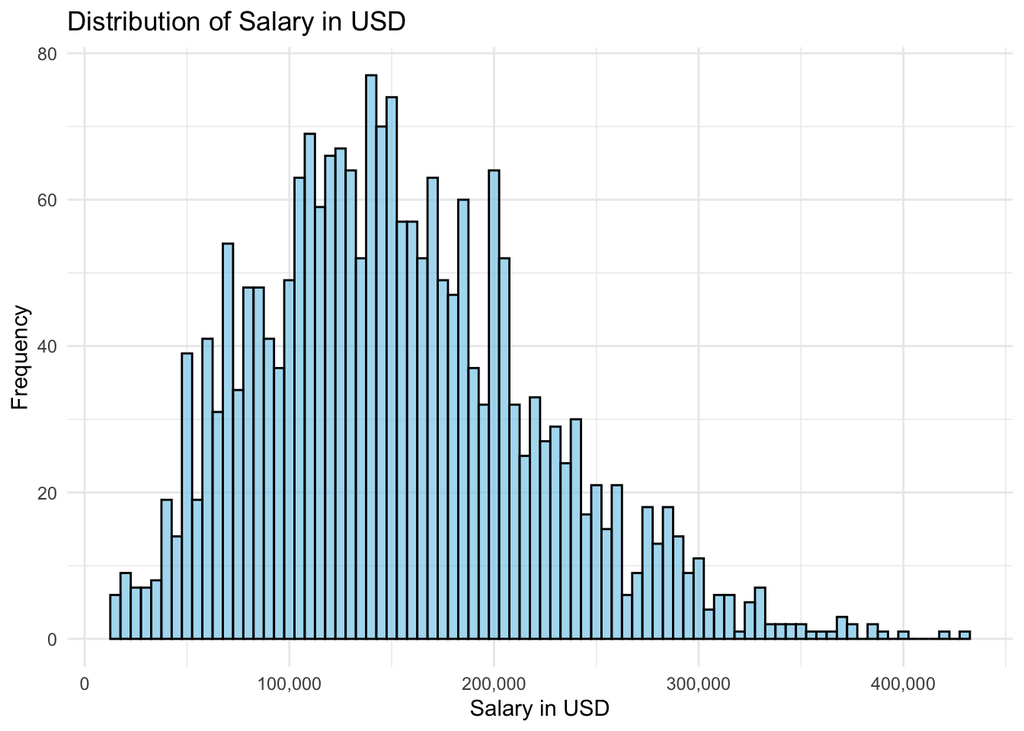

```r
# Histogram for Salary in USD
ggplot(salaries, aes(x = `Salary.in.USD`)) +
  geom_histogram(binwidth = 5000, fill = "skyblue", color = "black", alpha = 0.7) +
  labs(title = "Distribution of Salary in USD", x = "Salary in USD", y = "Frequency") +
  theme_minimal() +
  scale_x_continuous(labels = scales::comma) # normal numbers
```

From Histogram of Distribution of Salary in USD, we can see that our data is slightly right-skewed, which means most of our data points are in left side from mean, or less we could see this information in summary section as well, by comparing numbers. We believe that data contains a lot of valuable information, as for young researchers its interesting to analyze reasons for these deviations. # # # # # # # # #Bar plots

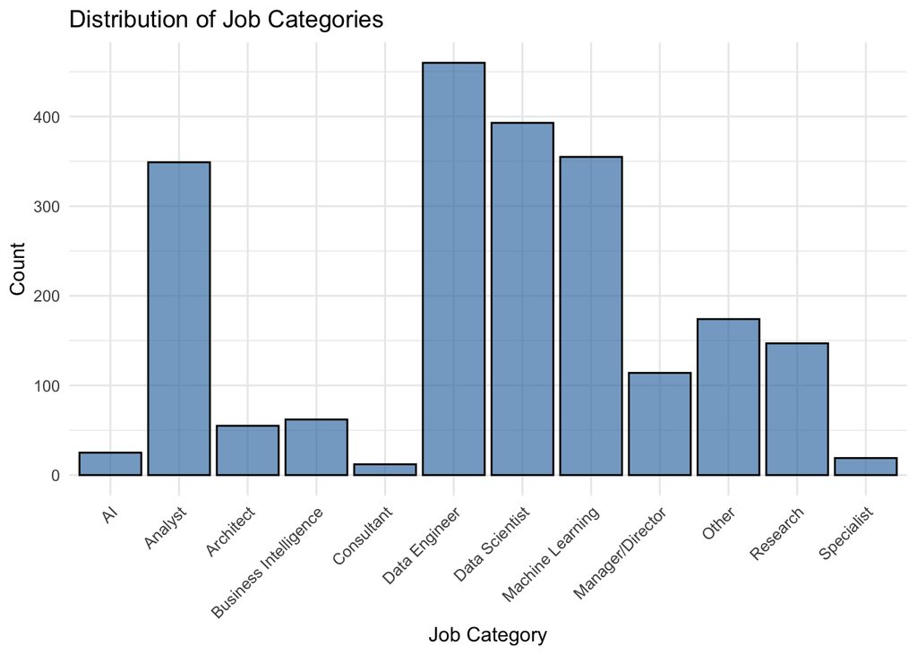

```r
# Bar plot for Job Title
# Bar plot for Job Category
ggplot(salaries, aes(x = `Job.Category`)) +
  geom_bar(fill = "steelblue", color = "black", alpha = 0.7) +
  labs(title = "Distribution of Job Categories", x = "Job Category", y = "Count") +
  theme_minimal() +
  theme(axis.text.x = element_text(angle = 45, hjust = 1))
```

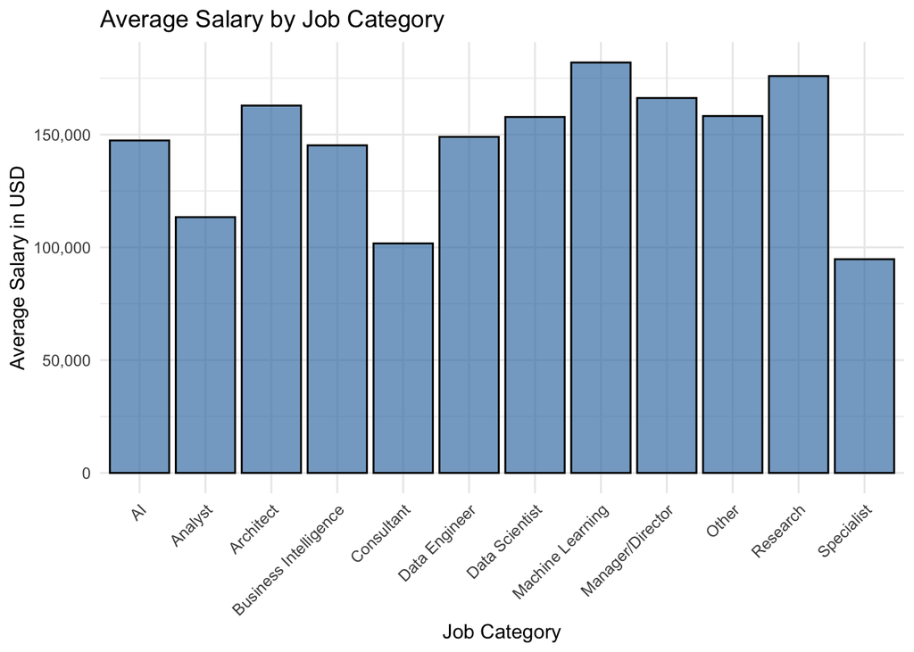

```r
# Aggregate data by Job Category to calculate average salaries
avg_salaries <- salaries %>%
  group_by(`Job.Category`) %>%
  summarize(Avg_Salary = mean(`Salary.in.USD`))

# Bar plot for average salaries by Job Category
ggplot(avg_salaries, aes(x = `Job.Category`, y = Avg_Salary)) +
  geom_bar(stat = "identity", fill = "steelblue", color = "black", alpha = 0.7) +
  labs(title = "Average Salary by Job Category", x = "Job Category", y = "Average Salary in USD") +
  theme_minimal() +
  theme(axis.text.x = element_text(angle = 45, hjust = 1)) +
  scale_y_continuous(labels = scales::comma) # Human-readable format for y-axis
```

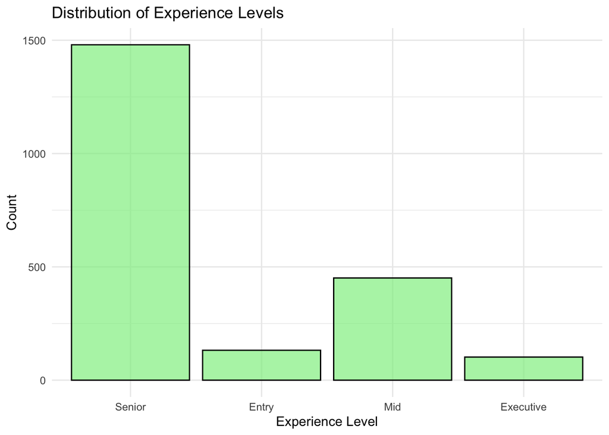

```r
# Bar plot for Experience Level
ggplot(salaries, aes(x = `Experience.Level`)) +
  geom_bar(fill = "lightgreen", color = "black", alpha = 0.7) +
  labs(title = "Distribution of Experience Levels", x = "Experience Level", y = "Count") +
  theme_minimal()
```

```r
new_salaries <- salaries %>%
                select(Salary.in.USD, Employment_Type_Dummy, Experience.Level,
                       Company.Size, Location_Dummy, Residency_Dummy, Has_Big,
                       Has_Data, Job.Category)
colnames(new_salaries) <- gsub("\\.", "_", colnames(new_salaries))
```

```r
set.seed(123)  # Setting seed ensures reproducibility

# Splitting data into training and testing sets
index <- createDataPartition(new_salaries$`Salary_in_USD`, p = 0.7, list = FALSE)
train_data <- new_salaries[index, ]
test_data  <- new_salaries[-index, ]
```

Data Splitting this will be vital for further modeling steps. By choosing 0.7 for p, we allocate 70% of our data for training, and 30% for testing. We choose this approach to have sufficient amount of data for testing, meanwhile making ability of training optimal. Ofcourse this selection, could be matter for discussion. # # # # # # # # #Model Building (Simple Models)

```r
# Linear Regression
lm_model <- lm(`Salary_in_USD` ~ ., data = train_data)
lm_predictions <- predict(lm_model, newdata = test_data)
lm_predictions_train <- predict(lm_model, newdata = train_data)
summary(lm_model)
```

```
##
## Call:
## lm(formula = Salary_in_USD ~ ., data = train_data)
##
## Residuals:
##     Min      1Q  Median      3Q     Max
## -157612  -42997   -7480   33833  296124
##
## Coefficients:
##                                   Estimate Std. Error t value Pr(>|t|)
## (Intercept)                          58424      32239   1.812  0.07016 .
## Employment_Type_Dummy                31448      26083   1.206  0.22813
## Experience_LevelEntry               -60298       6779  -8.895  < 2e-16 ***
## Experience_LevelMid                 -38399       3929  -9.773  < 2e-16 ***
## Experience_LevelExecutive            25202       7690   3.277  0.00107 **
## Company_SizeSmall                   -34252      14788  -2.316  0.02068 *
## Company_SizeMedium                    5236       7008   0.747  0.45511
## Location_Dummy1                      40483      22498   1.799  0.07215 .
## Residency_Dummy1                     36174      20637   1.753  0.07983 .
## Has_Big                             -70696      59716  -1.184  0.23665
## Has_Data                            -22310      11264  -1.981  0.04780 *
## Job_CategoryAnalyst                 -15710      18291  -0.859  0.39055
## Job_CategoryArchitect                20613      21008   0.981  0.32667
## Job_CategoryBusiness Intelligence   -21150      17141  -1.234  0.21744
## Job_CategoryConsultant              -26335      27006  -0.975  0.32965
## Job_CategoryData Engineer             8225      18467   0.445  0.65608
## Job_CategoryData Scientist           21740      18526   1.174  0.24078
## Job_CategoryMachine Learning         24715      14748   1.676  0.09398 .
## Job_CategoryManager/Director         21510      19390   1.109  0.26748
## Job_CategoryOther                     1151      15326   0.075  0.94017
## Job_CategoryResearch                 21731      15242   1.426  0.15417
## Job_CategorySpecialist              -25469      23799  -1.070  0.28472
## ---
## Signif. codes:  0 '***' 0.001 '**' 0.01 '*' 0.05 '.' 0.1 ' ' 1
##
## Residual standard error: 59540 on 1495 degrees of freedom
## Multiple R-squared:  0.2669, Adjusted R-squared:  0.2566
## F-statistic: 25.92 on 21 and 1495 DF,  p-value: < 2.2e-16
```

```r
# Decision Trees
tree_model <- rpart(`Salary_in_USD` ~ ., data = train_data, method = "anova")
tree_predictions <- predict(tree_model, test_data)
tree_predictions_train <- predict(tree_model, train_data)
summary(tree_model)
```

```
## Call:
## rpart(formula = Salary_in_USD ~ ., data = train_data, method = "anova")
##   n= 1517
##
##           CP nsplit rel error    xerror       xstd
## 1 0.12023017      0 1.0000000 1.0011445 0.03867859
## 2 0.04643288      1 0.8797698 0.8819183 0.03613100
## 3 0.02393392      2 0.8333370 0.8505682 0.03524862
## 4 0.01840246      3 0.8094030 0.8440052 0.03427707
## 5 0.01228005      4 0.7910006 0.8234112 0.03380130
## 6 0.01000000      5 0.7787205 0.8152827 0.03359901
##
## Variable importance
## Experience_Level     Job_Category         Has_Data  Residency_Dummy
##               44               34               10                7
##   Location_Dummy     Company_Size
##                5                1
##
## Node number 1: 1517 observations,    complexity param=0.1202302
##   mean=153568.4, MSE=4.765708e+09
##   left son=2 (405 obs) right son=3 (1112 obs)
##   Primary splits:
##       Experience_Level splits as  RLLR,         improve=0.12023020, (0 missing)
##       Job_Category     splits as  LLRRLRRRRRRL, improve=0.07626417, (0 missing)
##       Residency_Dummy  splits as  LR,           improve=0.06620847, (0 missing)
##       Location_Dummy   splits as  LR,           improve=0.05613862, (0 missing)
##       Has_Data         < 0.5 to the right,      improve=0.04550999, (0 missing)
##   Surrogate splits:
##       Residency_Dummy splits as  LR,           agree=0.746, adj=0.047, (0 split)
##       Location_Dummy  splits as  LR,           agree=0.741, adj=0.030, (0 split)
##       Job_Category    splits as  LRRRRRRRRRRL, agree=0.740, adj=0.025, (0 split)
##       Company_Size    splits as  RLR,          agree=0.736, adj=0.012, (0 split)
##
## Node number 2: 405 observations,    complexity param=0.02393392
##   mean=113904.5, MSE=3.640131e+09
##   left son=4 (287 obs) right son=5 (118 obs)
##   Primary splits:
##       Job_Category    splits as  LLLLLLLRLRRL, improve=0.11736940, (0 missing)
##       Residency_Dummy splits as  LR,           improve=0.10277150, (0 missing)
##       Location_Dummy  splits as  LR,           improve=0.09086109, (0 missing)
```

[output cut: 44 more lines]

```
##   Surrogate splits:
##       Has_Data     < 0.5 to the right, agree=0.813, adj=0.473, (0 split)
##       Company_Size splits as  LRL,     agree=0.647, adj=0.003, (0 split)
##
## Node number 8: 25 observations
##   mean=43713.56, MSE=7.789806e+08
##
## Node number 9: 262 observations
##   mean=106083.7, MSE=2.387274e+09
##
## Node number 14: 613 observations
##   mean=166449, MSE=3.748955e+09
##
## Node number 15: 336 observations
##   mean=191207.7, MSE=4.893436e+09
```

Linear Regression- The median residual value is -7480, indicating that the model’s median prediction was $7,480 higher than the actual salary. Employment_Type_Dummy has a positive coefficient, indicating that this type of employment generally leads to higher salaries. Experience levels such as “Entry” and “Mid” have negative coefficients, suggesting that these levels earn less compared to the baseline (probably “Senior”). Conversely, the “Executive” level has a positive coefficient, indicating higher salaries.Company size impacts the salary, with “Small” companies typically paying less. The Location_Dummy1 and Residency_Dummy1 variables, while not statistically significant at a 0.05 level, indicate potential salary differences based on location and residency. The presence of the word “Big” (Has_Big) in job titles/descriptions seems to decrease the salary, while “Data” (Has_Data) has a similar negative effect but is statistically significant at the 0.05 level. Various job categories have different impacts on the salary. Most of them are not statistically significant, but their presence provides insights into potential salary variations across roles. The Multiple R-squared value is 0.2669, meaning that the model explains approximately 26.69% of the variance in salaries. This suggests there’s a lot of unexplained variance, and while the model has some predictive power, there’s room for improvement. The F-statistic and its associated p-value test the overall significance of the model. The extremely low p-value (< 2.2e-16) suggests that the model is statistically significant and that at least some predictors help in predicting the salary. The Adjusted R-squared value is slightly lower than the R-squared, accounting for the number of predictors in the model. It indicates that about 25.66% of the variance in salaries is explained by the model after adjusting for the number of predictors. Tree Model- The “CP” (Complexity Parameter) values tell us the relative importance of each split. Smaller CP values indicate less important splits. The tree is built until the CP value decreases below a specified threshold, which is 0.01 for us. The most critical predictor in this tree is Experience_Level, accounting for 44% of the splits’ importance which is in line with linear regression, followed by Job_Category (34%) and Has_Data (10%). Its result about Job Category is interesting as significance level for this variable was pretty less in linear regression. Node number 1 is the root node containing all 1517 observations. The primary split is made on Experience_Level, dividing the data into left (Node 2) and right (Node 3) children nodes. Node 2 further splits on Job_Category, and Node 3 splits on the same. Nodes like 5, 6, 8, 9, 14, and 15 are terminal nodes or leaves. The mean value in these nodes represents the predicted Salary_in_USD for observations that end up in that node. As backup rules for making a split if the primary rule does not apply (e.g. due to missing data). For example, if Experience_Level is missing in Node 1, the surrogate split Residency_Dummy could be used. The rel error represents the proportion of total sum of squares remaining in the data before the split, and the xerror (cross-validated error) is an estimate of prediction error. A lower xerror indicates better predictive accuracy. The xstd gives an estimate of the standard error of the xerror. # # # # #  
#Plotting LM model results

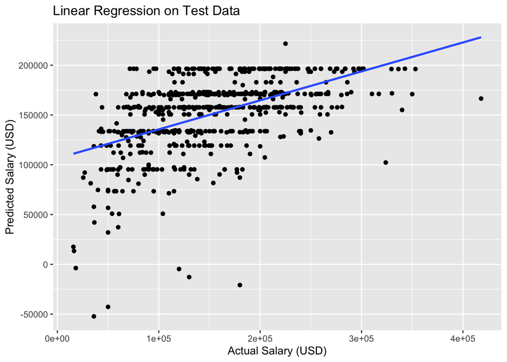

```r
if (!requireNamespace("ggplot2", quietly = TRUE)) {
  install.packages("ggplot2")
}

# Creating a data frame for plotting
plot_data <- data.frame(Actual = test_data$Salary_in_USD,
                         Predicted = lm_predictions)

# Creating scatterplot and add regression lines
scatterplot <- ggplot(plot_data, aes(x = Actual, y = Predicted)) +
  geom_point() +
  geom_smooth(method = "lm", formula = y ~ x, se = FALSE) +
  labs(title = "Linear Regression on Test Data",
       x = "Actual Salary (USD)",
       y = "Predicted Salary (USD)")

# Print the scatterplot
print(scatterplot)
```

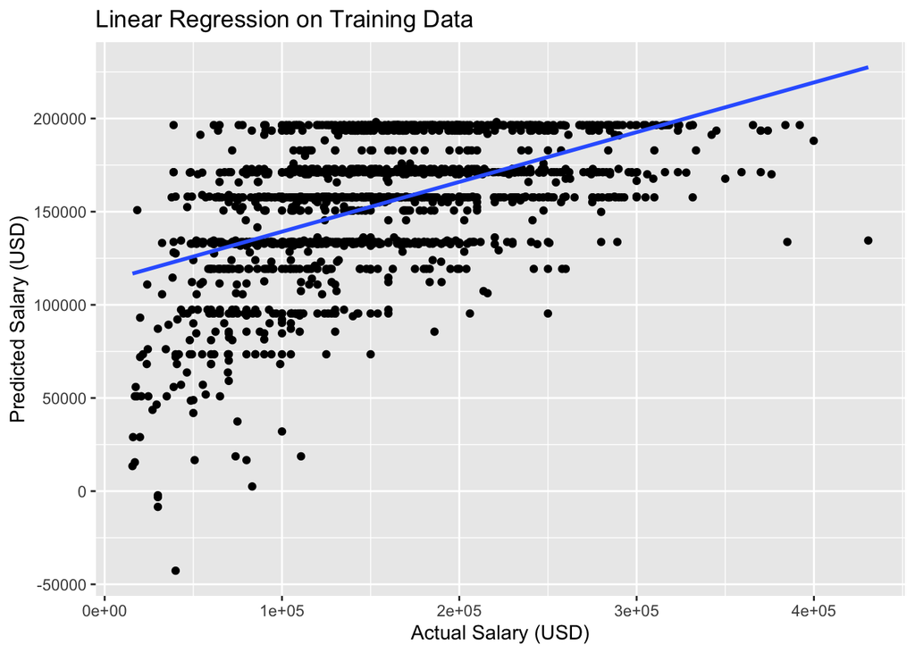

```r
# Repeating the process for the training data
plot_data_train <- data.frame(Actual = train_data$Salary_in_USD,
                               Predicted = lm_predictions_train)

scatterplot_train <- ggplot(plot_data_train, aes(x = Actual, y = Predicted)) +
  geom_point() +
  geom_smooth(method = "lm", formula = y ~ x, se = FALSE) +
  labs(title = "Linear Regression on Training Data",
       x = "Actual Salary (USD)",
       y = "Predicted Salary (USD)")

# print the scatterplot for training data
print(scatterplot_train)
```

From above mentioned graph, we can see that data is wide spread, however linear regression has some explanatory power or pattern. # # # # #  
#Model Evaluation of Linear regression and decision trees

```r
# For Linear Regression:
lm_mae <- mean(abs(test_data$`Salary_in_USD` - lm_predictions))
lm_rmse <- sqrt(mean((test_data$`Salary_in_USD` - lm_predictions)^2))
lm_mae_train <- mean(abs(train_data$`Salary_in_USD` - lm_predictions_train))
lm_rmse_train <- sqrt(mean((train_data$`Salary_in_USD` - lm_predictions_train)^2))

# For Decision Trees:
tree_mae <- mean(abs(test_data$`Salary_in_USD` - tree_predictions))
tree_rmse <- sqrt(mean((test_data$`Salary_in_USD` - tree_predictions)^2))
tree_mae_train <- mean(abs(train_data$`Salary_in_USD` - tree_predictions_train))
tree_rmse_train <- sqrt(mean((train_data$`Salary_in_USD` - tree_predictions_train)^2))
```

# # # #

#Visualise model results

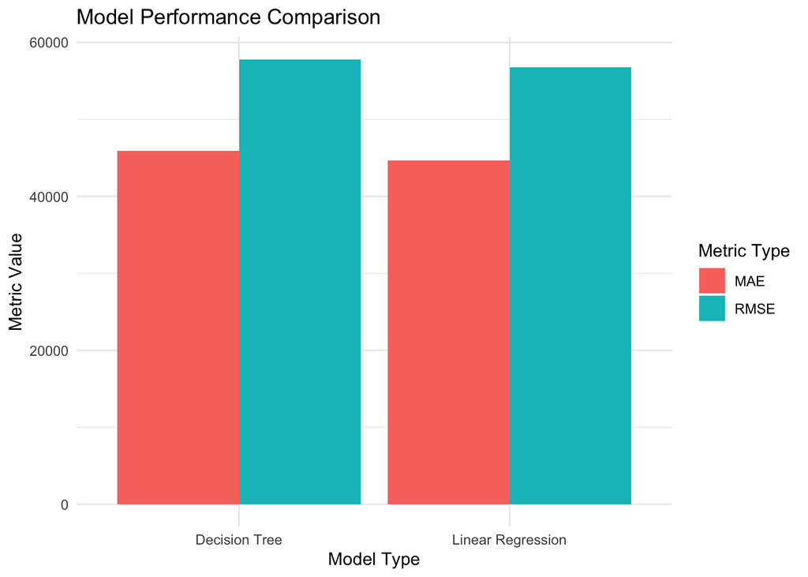

```r
# Prepare data for visualization
comparison_data <- data.frame(
  Model = c("Linear Regression", "Decision Tree", "Linear Regression", "Decision Tree"),
  Metric_Value = c(lm_mae, tree_mae, lm_rmse, tree_rmse),
  Metric_Type = rep(c("MAE", "RMSE"), each = 2)
)

# Bar plot using ggplot2
ggplot(comparison_data, aes(x = Model, y = Metric_Value, fill = Metric_Type)) +
  geom_bar(stat = "identity", position = "dodge") +
  labs(title = "Model Performance Comparison",
       y = "Metric Value",
       x = "Model Type",
       fill = "Metric Type") +
  theme_minimal()
```

MAE is the average of the absolute differences between the predicted and actual values. It gives an idea of how wrong the predictions were. RMSE gives an idea of how concentrated the data is around the line of best fit. A lower MAE indicates a better fit to the data. There is no huge difference between these MAE and RMSE, so we can not say that there is presence of large errors. Considering MAE and RMSE being proportionally less than Decision tree, results show that Lineaar Regression is better fit for the data than Decision tree, it not only predicts better but has fewer instances for large prediction errors. # # # # #  
#Advance Modeling (Random forest and Neural Network)

```r
#Randon Forest
rf_model <- randomForest(`Salary_in_USD` ~ ., data = train_data)
rf_predictions <- predict(rf_model, test_data)
rf_predictions_training <- predict(rf_model, train_data)
# For Random Forest:
#MSE For testıng
forest_mae <- mean(abs(test_data$`Salary_in_USD` - rf_predictions))
forest_rmse <- sqrt(mean((test_data$`Salary_in_USD` - rf_predictions)^2))
#MSE For traınıng
forest_mae_training  <- mean(abs(train_data$`Salary_in_USD` - rf_predictions_training))
forest_rmse_training <- sqrt(mean((train_data$`Salary_in_USD` - rf_predictions_training)^2))
forest_mae
```

```
## [1] 45146.38
```

```r
forest_rmse
```

```
## [1] 56653.31
```

```r
forest_mae_training
```

```
## [1] 46288.91
```

```r
forest_rmse_training
```

```
## [1] 59184.22
```

```r
#Neural Network
nn_model <- nnet(`Salary_in_USD` ~ ., data = train_data,learningrate=0.005, linout = TRUE,size = 10)
nn_predictions <- predict(nn_model, test_data)
nn_predictionstrain <- predict(nn_model, train_data)
neural_mae <- mean(abs(test_data$`Salary_in_USD` - nn_predictions))
neural_rmse <- sqrt(mean((test_data$`Salary_in_USD` - nn_predictions)^2))

neural_maetr <- mean(abs(train_data$`Salary_in_USD` - nn_predictionstrain))
neural_rmsetr <- sqrt(mean((train_data$`Salary_in_USD` - nn_predictionstrain)^2))
```

```r
# Fit the neural network using the significant predictors
set.seed(123)
nn_fit <- train(
  Salary_in_USD ~ .,
  data = new_salaries,
  method = "nnet",
  linout = TRUE,
  trace = FALSE,
  tuneGrid = expand.grid(.size = c(6, 8, 10), .decay = c(0.1, 0.5, 1)),
  trControl = trainControl(
    method = "cv",
    number = 5,
    repeats = 0, #previously was set to 3 results were exactly same so it didnt make any change.
    verboseIter = TRUE
  )
)
```

```
## Warning in nominalTrainWorkflow(x = x, y = y, wts = weights, info = trainInfo,
## : There were missing values in resampled performance measures.
```

```r
nn_fit$results
```

```
##   size decay     RMSE  Rsquared      MAE   RMSESD RsquaredSD    MAESD
## 1    6   0.1 66740.47 0.1953299 53191.52 4831.937         NA 3484.711
## 2    6   0.5 63784.10 0.1980148 50240.97 3486.660 0.05791319 3232.356
## 3    6   1.0 63115.25 0.1935626 49417.97 2524.751 0.02749816 2201.634
## 4    8   0.1 66867.57 0.1787317 53263.26 4558.056         NA 3329.264
## 5    8   0.5 64120.95 0.1387693 50303.12 4175.644 0.10874045 3496.012
## 6    8   1.0 62372.50 0.2032567 48855.52 1726.513 0.04145207 1964.436
## 7   10   0.1 66652.22 0.2022122 52942.94 4246.783         NA 3422.100
## 8   10   0.5 63826.37 0.2186128 50137.59 2990.841 0.05035376 3027.992
## 9   10   1.0 61615.95 0.1843054 48292.75 2856.856 0.03451286 1883.564
```

```r
train_data_dummies <- model.matrix(Salary_in_USD ~ . - 1, data = train_data) # '- 1' removes intercept
test_data_dummies <- model.matrix(Salary_in_USD ~ . - 1, data = test_data)
scaled_train_data <- scale(train_data_dummies)
scaled_test_data <- scale(test_data_dummies)
pca_train <- prcomp(scaled_train_data, center = TRUE, scale. = TRUE)
pca_test <- prcomp(scaled_test_data, center = TRUE, scale. = TRUE)
#PCA to Linear Regression
lm_model_pca <- lm(Salary_in_USD ~ ., data = data.frame(Salary_in_USD = train_data$Salary_in_USD, pca_train$x))
lm_predictions_pca <- predict(lm_model_pca, newdata = data.frame(pca_test$x))
#PCA to Decision Tree
tree_model_pca <- rpart(Salary_in_USD ~ ., data = data.frame(Salary_in_USD = train_data$Salary_in_USD, pca_train$x))
tree_predictions_pca <- predict(tree_model_pca, newdata = data.frame(pca_test$x))
#PCA to Random Forest
rf_model_pca <- randomForest(Salary_in_USD ~ ., data = data.frame(Salary_in_USD = train_data$Salary_in_USD, pca_train$x))
rf_predictions_pca <- predict(rf_model_pca, newdata = data.frame(pca_test$x))
#PCA to Neural Network
library(nnet)
nn_model_pca <- nnet(Salary_in_USD ~ ., data = data.frame(Salary_in_USD = train_data$Salary_in_USD, pca_train$x), size = 10, linout = TRUE)
nn_predictions_pca <- predict(nn_model_pca, newdata = data.frame(pca_test$x))
```

```r
# MAE and RMSE for Linear Regression model with PCA
lm_mae_pca <- mean(abs(test_data$Salary_in_USD - lm_predictions_pca))
lm_rmse_pca <- sqrt(mean((test_data$Salary_in_USD - lm_predictions_pca)^2))

cat("Linear Regression with PCA - MAE:", lm_mae_pca, "\n")
```

```
## Linear Regression with PCA - MAE: 7449419
```

```r
cat("Linear Regression with PCA - RMSE:", lm_rmse_pca, "\n")
```

```
## Linear Regression with PCA - RMSE: 8343630
```

```r
# MAE and RMSE for Decision Trees model with PCA
tree_mae_pca <- mean(abs(test_data$Salary_in_USD - tree_predictions_pca))
tree_rmse_pca <- sqrt(mean((test_data$Salary_in_USD - tree_predictions_pca)^2))

cat("Decision Tree with PCA - MAE:", tree_mae_pca, "\n")
```

```
## Decision Tree with PCA - MAE: 48971.56
```

```r
cat("Decision Tree with PCA - RMSE:", tree_rmse_pca, "\n")
```

```
## Decision Tree with PCA - RMSE: 61577.21
```

```r
# MAE and RMSE for Random Forest model with PCA
rf_mae_pca <- mean(abs(test_data$Salary_in_USD - rf_predictions_pca))
rf_rmse_pca <- sqrt(mean((test_data$Salary_in_USD - rf_predictions_pca)^2))

cat("Random Forest with PCA - MAE:", rf_mae_pca, "\n")
```

```
## Random Forest with PCA - MAE: 50183.48
```

```r
cat("Random Forest with PCA - RMSE:", rf_rmse_pca, "\n")
```

```
## Random Forest with PCA - RMSE: 64335.64
```

```r
# MAE and RMSE for Neural Network model with PCA
nn_mae_pca <- mean(abs(test_data$Salary_in_USD - nn_predictions_pca))
nn_rmse_pca <- sqrt(mean((test_data$Salary_in_USD - nn_predictions_pca)^2))

cat("Neural Network with PCA - MAE:", nn_mae_pca, "\n")
```

```
## Neural Network with PCA - MAE: 48985.14
```

```r
cat("Neural Network with PCA - RMSE:", nn_rmse_pca, "\n")
```

```
## Neural Network with PCA - RMSE: 61401.84
```

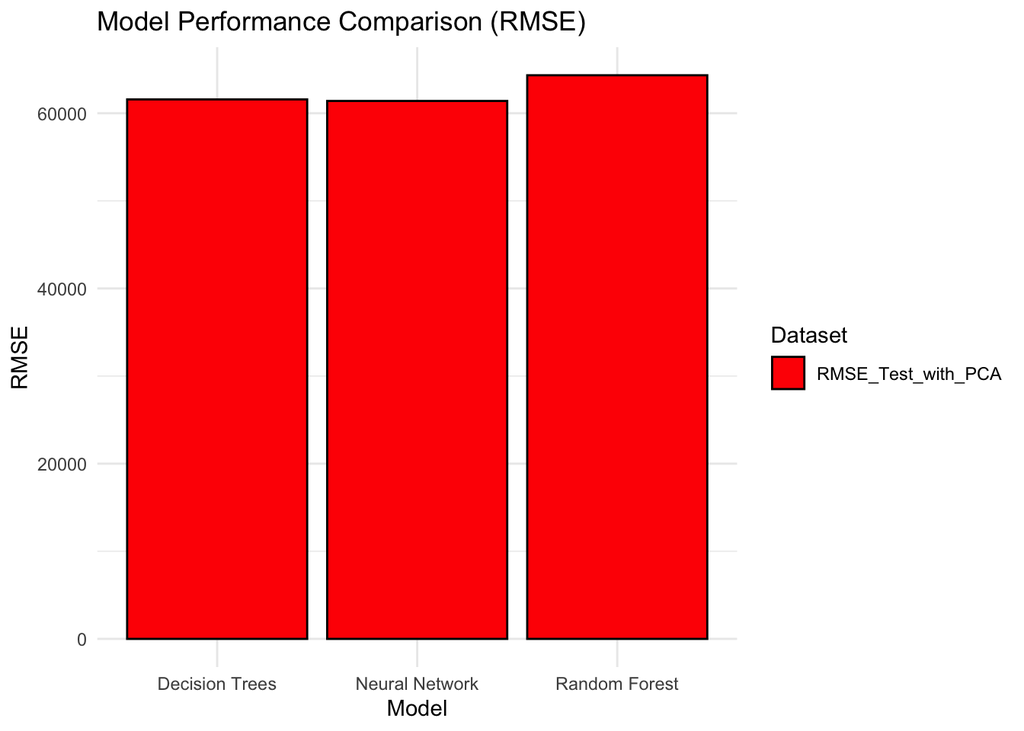

```r
metrics_df_pca <- data.frame(
  Model = c("Decision Trees", "Random Forest", "Neural Network"),
  RMSE_Test_with_PCA = c(tree_rmse_pca, rf_rmse_pca, nn_rmse_pca)
)
# Reshape the data frame
metrics_df_pca <- metrics_df_pca %>%
  pivot_longer(cols = starts_with("RMSE"), names_to = "Dataset", values_to = "RMSE_Value")

# Create the bar plot with custom colors
ggplot(metrics_df_pca, aes(x = Model, y = RMSE_Value, fill = Dataset)) +
  geom_bar(stat = "identity", position = "dodge", color = "black") +
  scale_fill_manual(values = c("red", "blue")) +
  labs(title = "Model Performance Comparison (RMSE)",
       y = "RMSE",
       x = "Model") +
  theme_minimal()
```

Here in this plot we can better see differences on RMSE of models with PCA. As stated above, Linear Regression performed worst among these models, and including its result negatively affect visibility of the illustration so we decided to excluded it. # # # # #  
#Compare RMSE for Linear Regression and Neural Networks analysis based on both train and test data

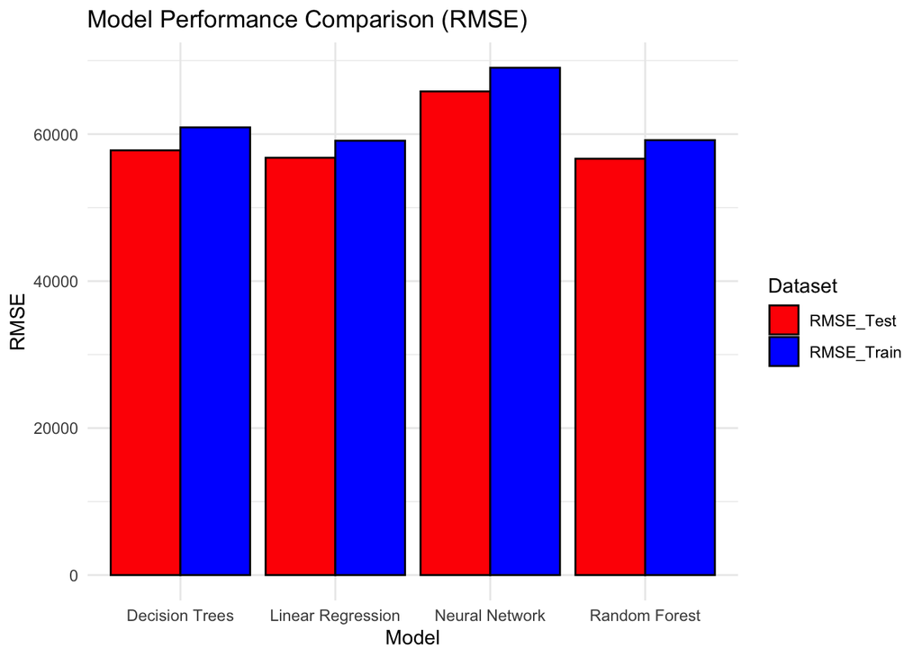

```r
# Comapring
metrics_df <- data.frame(
  Model = c("Linear Regression", "Decision Trees", "Random Forest", "Neural Network"),
  RMSE_Test = c(lm_rmse, tree_rmse, forest_rmse, neural_rmse),
  RMSE_Train = c(lm_rmse_train, tree_rmse_train, forest_rmse_training, neural_rmsetr)
)

# Reshape the data frame
metrics_df <- metrics_df %>%
  pivot_longer(cols = starts_with("RMSE"), names_to = "Dataset", values_to = "RMSE_Value")

# Create the bar plot with preferred colors
ggplot(metrics_df, aes(x = Model, y = RMSE_Value, fill = Dataset)) +
  geom_bar(stat = "identity", position = "dodge", color = "black") +
  scale_fill_manual(values = c("red", "blue")) +
  labs(title = "Model Performance Comparison (RMSE)",
       y = "RMSE",
       x = "Model") +
  theme_minimal()
```

To compare above-mentioned plot with previous one we see that, applying PCA negative impact on all models except Neural Potential reason is that these three are traditional machine learning algorithms that don’t inherently benefit from dimensionality reduction through PCA. PCA can sometimes lead to information loss because it projects the data onto a lower-dimensional space while trying to preserve variance. The decrease in RMSE for the Neural Network suggests that the reduced-dimensional data produced by PCA provides a more suitable input for the network. It’s possible that PCA helped in simplifying the problem or reducing noise in the data, making it easier for the neural network to learn meaningful patterns. # # # # #  
#Calculation of Rsquare for models with and without PCA

```r
# For Linear Regression with PCA
lm_r2_pca <- 1 - sum((test_data$Salary_in_USD - lm_predictions_pca)^2) / sum((test_data$Salary_in_USD - mean(test_data$Salary_in_USD))^2)

# For Decision Tree with PCA
tree_r2_pca <- 1 - sum((test_data$Salary_in_USD - tree_predictions_pca)^2) / sum((test_data$Salary_in_USD - mean(test_data$Salary_in_USD))^2)

# For Random Forest with PCA
rf_r2_pca <- 1 - sum((test_data$Salary_in_USD - rf_predictions_pca)^2) / sum((test_data$Salary_in_USD - mean(test_data$Salary_in_USD))^2)

# For Neural Network with PCA
nn_r2_pca <- 1 - sum((test_data$Salary_in_USD - nn_predictions_pca)^2) / sum((test_data$Salary_in_USD - mean(test_data$Salary_in_USD))^2)

# For Linear Regression
lm_r2 <- 1 - sum((test_data$Salary_in_USD - lm_predictions)^2) / sum((test_data$Salary_in_USD - mean(test_data$Salary_in_USD))^2)

# For Decision Tree
tree_r2 <- 1 - sum((test_data$Salary_in_USD - tree_predictions)^2) / sum((test_data$Salary_in_USD - mean(test_data$Salary_in_USD))^2)

# For Random Forest
rf_r2 <- 1 - sum((test_data$Salary_in_USD - rf_predictions)^2) / sum((test_data$Salary_in_USD - mean(test_data$Salary_in_USD))^2)

# For Neural Network
nn_r2 <- 1 - sum((test_data$Salary_in_USD - nn_predictions)^2) / sum((test_data$Salary_in_USD - mean(test_data$Salary_in_USD))^2)
```

# # # #

#Plotting of Rsquared results for Models with and without PCA

```r
# Create the table
r2_data <- data.frame(
  Model = c('Linear Regression', 'Decision Tree', 'Random Forest', 'Neural Network',
            'Linear Regression PCA', 'Decision Tree PCA', 'Random Forest PCA', 'Neural Network PCA'),
  R_Squared = c(lm_r2, tree_r2, rf_r2, nn_r2, lm_r2_pca, tree_r2_pca, rf_r2_pca, nn_r2_pca)
)

r2_table <- r2_data %>%
  gt() %>%
  tab_header(
    title = "R^2 Values for Models"
  ) %>%
  tab_options(
    table.background.color = "white",
    table.font.color = "black"
  )

# Display the table
r2_table
```

R^2 Values for Models

| Model | R_Squared |
| --- | --- |
| Linear Regression | 2.552985e-01 |
| Decision Tree | 2.287022e-01 |
| Random Forest | 2.588696e-01 |
| Neural Network | -3.035407e-04 |
| Linear Regression PCA | -1.607412e+04 |
| Decision Tree PCA | 1.244438e-01 |
| Random Forest PCA | 4.424340e-02 |
| Neural Network PCA | 1.294238e-01 |